# My Achievement:

This assignment provided me with valuable hands-on experience in data preprocessing, analysis, and visualization. I successfully cleaned and processed a real-world dataset of tweets by handling missing values and analyzing airline sentiment. Through calculating and visualizing sentiment confidence levels, I gained insights into trends across different airlines. Additionally, I applied TF-IDF vectorization to transform textual data into numerical features, showcasing the ability to convert unstructured data into a format suitable for machine learning and further analysis. Overall, this assignment enhanced my understanding of practical tools such as Pandas, Matplotlib, and Scikit-learn.

# ✍ Student: Mohammad Osmanpoor

# 🏢 University: Macquarie University

# 📅 Assignment: Week 2 Workshop

### ✍ 1. Use Pandas to load the dataset "data/Tweets.csv". Check if missing values exist in the data set. For each of the columns having missing values, do we need to remove the whole column or perform missing value imputation? Justify your answers. If we need to perform imputation, please do that.

Hint: If you decide to remove any column, use the drop() method from DataFrame.

```python
# my todo:
# find number of missing values
# why we need remove or why we need imputation. find reason for each column
# use drop() method for removing columns

# my thumbs of rule :
# drop columns with >20% missing data.

# if impute missing values :
  # numerical columns: fill with the mean.
  # categorical columns: fill with the mode.
```

```python
import pandas as pd
import numpy as np

# load the dataset
tweets_data = pd.read_csv("Tweets.csv", header=0, na_filter=True, na_values="?")

# display a summary of the dataset to check for missing values
print("Dataset Info:")
print(tweets_data.info())
```

```
Dataset Info:
<class 'pandas.core.frame.DataFrame'>
RangeIndex: 14640 entries, 0 to 14639
Data columns (total 15 columns):
 #   Column                        Non-Null Count  Dtype
---  ------                        --------------  -----
 0   tweet_id                      14640 non-null  int64
 1   airline_sentiment             14640 non-null  object
 2   airline_sentiment_confidence  14640 non-null  float64
 3   negativereason                9178 non-null   object
 4   negativereason_confidence     10522 non-null  float64
 5   airline                       14640 non-null  object
 6   airline_sentiment_gold        40 non-null     object
 7   name                          14640 non-null  object
 8   negativereason_gold           32 non-null     object
 9   retweet_count                 14640 non-null  int64
 10  text                          14640 non-null  object
 11  tweet_coord                   1019 non-null   object
 12  tweet_created                 14640 non-null  object
 13  tweet_location                9907 non-null   object
 14  user_timezone                 9820 non-null   object
dtypes: float64(2), int64(2), object(11)
memory usage: 1.7+ MB
None
```

```python
# some sample of raw dataset
tweets_data.head(3)
```

|  | tweet_id | airline_sentiment | airline_sentiment_confidence | negativereason | negativereason_confidence | airline | airline_sentiment_gold | name | negativereason_gold | retweet_count | text | tweet_coord | tweet_created | tweet_location | user_timezone |
| --- | --- | --- | --- | --- | --- | --- | --- | --- | --- | --- | --- | --- | --- | --- | --- |
| 0 | 570306133677760513 | neutral | 1.0000 | NaN | NaN | Virgin America | NaN | cairdin | NaN | 0 | @VirginAmerica What @dhepburn said. | NaN | 2015-02-24 11:35:52 -0800 | NaN | Eastern Time (US & Canada) |
| 1 | 570301130888122368 | positive | 0.3486 | NaN | 0.0 | Virgin America | NaN | jnardino | NaN | 0 | @VirginAmerica plus you've added commercials t... | NaN | 2015-02-24 11:15:59 -0800 | NaN | Pacific Time (US & Canada) |
| 2 | 570301083672813571 | neutral | 0.6837 | NaN | NaN | Virgin America | NaN | yvonnalynn | NaN | 0 | @VirginAmerica I didn't today... Must mean I n... | NaN | 2015-02-24 11:15:48 -0800 | Lets Play | Central Time (US & Canada) |

```python
# check for missing values in each column
missing_values = tweets_data.isnull().sum()
print("\nMissing Values in Each Column:")
print(missing_values)

# analyze missing values and decide whether to drop or impute
columns_with_missing = missing_values[missing_values > 0]
print("\nColumns with Missing Values:")
print(columns_with_missing)
```

```
Missing Values in Each Column:
tweet_id                            0
airline_sentiment                   0
airline_sentiment_confidence        0
negativereason                   5462
negativereason_confidence        4118
airline                             0
airline_sentiment_gold          14600
name                                0
negativereason_gold             14608
retweet_count                       0
text                                0
tweet_coord                     13621
tweet_created                       0
tweet_location                   4733
user_timezone                    4820
dtype: int64

Columns with Missing Values:
negativereason                5462
negativereason_confidence     4118
airline_sentiment_gold       14600
negativereason_gold          14608
tweet_coord                  13621
tweet_location                4733
user_timezone                 4820
dtype: int64
```

```python
for col in columns_with_missing.index:
    # justification for handling missing values:
    # if the column has too many missing values or is not essential for analysis, we drop it.
    # otherwise, we perform imputation.

    print(f"\nHandling Missing Values for Column: {col}")
    missing_percentage = (missing_values[col] / len(tweets_data)) * 100
    print(f"Missing Percentage: {missing_percentage:.2f}%")

    if missing_percentage > 20:  # my arbitrary threshold for dropping
        print(f"Dropping column '{col}' due to high missing values.")
        tweets_data = tweets_data.drop(columns=[col])
    else:
        # for numerical columns, fill with mean value
        if tweets_data[col].dtype in [np.float64, np.int64]:
            print(f"Imputing missing values in '{col}' with the mean.")
            tweets_data[col] = tweets_data[col].fillna(tweets_data[col].mean())
        else:
            # for categorical columns, fill with the mode value
            print(f"Imputing missing values in '{col}' with the mode.")
            tweets_data[col] = tweets_data[col].fillna(tweets_data[col].mode()[0])
```

```
Handling Missing Values for Column: negativereason
Missing Percentage: 37.31%
Dropping column 'negativereason' due to high missing values.

Handling Missing Values for Column: negativereason_confidence
Missing Percentage: 28.13%
Dropping column 'negativereason_confidence' due to high missing values.

Handling Missing Values for Column: airline_sentiment_gold
Missing Percentage: 99.73%
Dropping column 'airline_sentiment_gold' due to high missing values.

Handling Missing Values for Column: negativereason_gold
Missing Percentage: 99.78%
Dropping column 'negativereason_gold' due to high missing values.

Handling Missing Values for Column: tweet_coord
Missing Percentage: 93.04%
Dropping column 'tweet_coord' due to high missing values.

Handling Missing Values for Column: tweet_location
Missing Percentage: 32.33%
Dropping column 'tweet_location' due to high missing values.

Handling Missing Values for Column: user_timezone
Missing Percentage: 32.92%
Dropping column 'user_timezone' due to high missing values.
```

```python
# verify there are no missing values left
print("\nMissing Values After Processing:")
print(tweets_data.isnull().sum())

# display the processed data
print("\nProcessed Dataset Head:")
tweets_data.head(3)
```

```
Missing Values After Processing:
tweet_id                        0
airline_sentiment               0
airline_sentiment_confidence    0
airline                         0
name                            0
retweet_count                   0
text                            0
tweet_created                   0
dtype: int64

Processed Dataset Head:
```

|  | tweet_id | airline_sentiment | airline_sentiment_confidence | airline | name | retweet_count | text | tweet_created |
| --- | --- | --- | --- | --- | --- | --- | --- | --- |
| 0 | 570306133677760513 | neutral | 1.0000 | Virgin America | cairdin | 0 | @VirginAmerica What @dhepburn said. | 2015-02-24 11:35:52 -0800 |
| 1 | 570301130888122368 | positive | 0.3486 | Virgin America | jnardino | 0 | @VirginAmerica plus you've added commercials t... | 2015-02-24 11:15:59 -0800 |
| 2 | 570301083672813571 | neutral | 0.6837 | Virgin America | yvonnalynn | 0 | @VirginAmerica I didn't today... Must mean I n... | 2015-02-24 11:15:48 -0800 |

```python
# save the cleaned dataset
tweets_data.to_csv("Cleaned_Tweets.csv", index=False)
```

### ✍2. Calculate the average "airline_sentiment_confidence" for each "airline". Plot bar chart to show the average "airline_sentiment_confidence" for each "airline".

Hint: Use DataFrame's .grouby() methods to group counts of each airline, and then use the plot.bar method.

```
Average Airline Sentiment Confidence:
airline
American          0.917352
Delta             0.869878
Southwest         0.886516
US Airways        0.921578
United            0.900878
Virgin America    0.876086
Name: airline_sentiment_confidence, dtype: float64
```

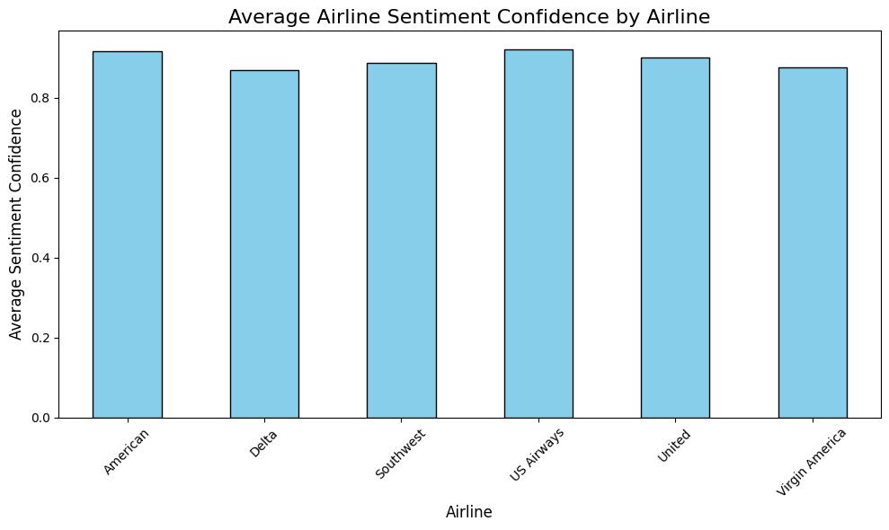

```python
import pandas as pd
import matplotlib.pyplot as plt

# load the cleaned dataset
tweets_data = pd.read_csv("Cleaned_Tweets.csv")

# group by "airline" and calculate the mean of "airline_sentiment_confidence"
average_confidence = tweets_data.groupby("airline")["airline_sentiment_confidence"].mean()

# print the calculated average confidence values
print("Average Airline Sentiment Confidence:")
print(average_confidence)

# plot a bar chart to display the average confidence for each airline
plt.figure(figsize=(10, 6))
average_confidence.plot(kind="bar", color="skyblue", edgecolor="black")
plt.title("Average Airline Sentiment Confidence by Airline", fontsize=16)
plt.xlabel("Airline", fontsize=12)
plt.ylabel("Average Sentiment Confidence", fontsize=12)
plt.xticks(rotation=45)
plt.tight_layout()

# display the plot
plt.show()
```

### ✍ 3. Use TF-IDF to transform the "text" column into a numerical feature vector. Refer to https://scikit-learn.org/stable/modules/generated/sklearn.feature_extraction.text.TfidfVectorizer.html for the details about how to achieve this in the sklearn module.

```python
from sklearn.feature_extraction.text import TfidfVectorizer

# extract the "text" column from the dataset
text = tweets_data['text']

# initialize the TF-IDF vectorizer
tfidf_vectorizer = TfidfVectorizer(max_features=500, stop_words='english')

# transform the "text" column into a TF-IDF feature matrix
tfidf_matrix = tfidf_vectorizer.fit_transform(text)

# convert the TF-IDF matrix to a dataframe
tfidf_df = pd.DataFrame(tfidf_matrix.toarray(), columns=tfidf_vectorizer.get_feature_names_out())

# display the first few rows of the TF-IDF dataFrame
print("TF-IDF Feature Matrix:")
print(tfidf_df.head())
```

```
TF-IDF Feature Matrix:
    10  100   11   12   15  1st   20  200   24   25  ...  worse  worst  \
0  0.0  0.0  0.0  0.0  0.0  0.0  0.0  0.0  0.0  0.0  ...    0.0    0.0
1  0.0  0.0  0.0  0.0  0.0  0.0  0.0  0.0  0.0  0.0  ...    0.0    0.0
2  0.0  0.0  0.0  0.0  0.0  0.0  0.0  0.0  0.0  0.0  ...    0.0    0.0
3  0.0  0.0  0.0  0.0  0.0  0.0  0.0  0.0  0.0  0.0  ...    0.0    0.0
4  0.0  0.0  0.0  0.0  0.0  0.0  0.0  0.0  0.0  0.0  ...    0.0    0.0

   wouldn  wow  wrong  yeah  year  years  yes  yesterday
0     0.0  0.0    0.0   0.0   0.0    0.0  0.0        0.0
1     0.0  0.0    0.0   0.0   0.0    0.0  0.0        0.0
2     0.0  0.0    0.0   0.0   0.0    0.0  0.0        0.0
3     0.0  0.0    0.0   0.0   0.0    0.0  0.0        0.0
4     0.0  0.0    0.0   0.0   0.0    0.0  0.0        0.0

[5 rows x 500 columns]
```

```python
# display the raw tweet and its corresponding TF-IDF vector
example_index = 0  # index of the tweet sample
print("Raw Tweet Example:")
print(text.iloc[example_index])
print("\nTF-IDF Vector for the Tweet:")
print(tfidf_df.iloc[example_index])
```

```
Raw Tweet Example:
@VirginAmerica What @dhepburn said.

TF-IDF Vector for the Tweet:
10           0.0
100          0.0
11           0.0
12           0.0
15           0.0
            ...
yeah         0.0
year         0.0
years        0.0
yes          0.0
yesterday    0.0
Name: 0, Length: 500, dtype: float64
```